# Predicting sales

# Team Members

Rachel Brigell, Emily Gao, Nina Punukollu

# Research question

Do factors associated with conventional wisdom about retail sales help to predict retail sales?

# Introduction

# 1. Load and wrangle the data

# Data

Sales: To obtain a proxy for sales that are occurring at these stores, we used the Twitter API to obtain data from their accounts and used keyword analysis to identify days where they had sales. We attempted to select stores that had comparable styles of clothing and types of consumers. We did not distinguish between online and in-store sales.

Weather: We used the WeatherUnderground API to obtain temperature and precipitation data from 4 major cities in different regions of the United States: LA, New York, Chicago, and Houston.

Unemployment: We obtained monthly unemployment statistics from the US Bureau of Labor Statistics

Stock prices: We obtained daily stock prices for the stores that are publicly listed from Yahoo Finance.

Holidays: We obtained US Holiday data from the R timeDate package.

# Wrangling: Weather Data

To measure seasonal weather patterns, we collected data using the WeatherUnderground API from four, highly populated cities in the United States: New York, Los Angeles, Chicago, and Houston. In the wrangling below, we selected mean temperature, amount of precipitation, and snow falls as variables to use in our analyses. We will later use these factors to estimate changes in seasons across the United States. We hypothesize that sales are more likely to happen as seasons changes.

```r
## Weather Wrangling - Creates One File for Weather
#######################################################################

# read in weather csv files for 4 cities
new_york <- read_csv("weather_NewYork_2013-2016.csv")
los_angeles <- read_csv("weather_LA_2013-2016.csv")
chicago <- read_csv("weather_Chicago_2013-2016.csv")
houston <- read_csv("weather_Houston_2013-2016.csv")

# keep date, snow, mean_temp, precipitation columns, rename columns
new_york <- new_york %>% select(date, snow, mean_temp, precip) %>%
  rename (ny_snow = snow, ny_mean_temp = mean_temp,
          ny_precip = precip)

los_angeles <- los_angeles %>% select(date, snow, mean_temp, precip) %>%
  rename (la_snow = snow, la_mean_temp = mean_temp,
          la_precip = precip)

chicago <- chicago %>% select(date, snow, mean_temp, precip) %>%
  rename (chi_snow = snow, chi_mean_temp = mean_temp,
          chi_precip = precip)

houston <- houston %>% select(date, snow, mean_temp, precip) %>%
  rename (hou_snow = snow, hou_mean_temp = mean_temp,
          hou_precip = precip)

# join weather data from 4 cities together
ny_la <- full_join(new_york, los_angeles, by = "date")
ny_la_chi <- full_join(ny_la, chicago, by = "date")
weather <- full_join(ny_la_chi, houston, by = "date")
```

# Wrangling: Stock Price Data

We collected historical stock prices from Yahoo Finance for three of the four stores we are using in our analyses: Gap, Loft, and Express. We did not collect data from J Crew because J Crew is a privately held company. To measure stock prices, we are using the adjusted stock price, because it is the price that captures the total return (including dividends or spits). We hypothesize that a store’s stock performance will impact weather or not the store has a sale (as store struggle financially, they may be more likely to hold sales).

```r
## Stock Wrangling - Create individual store files for stock prices
#######################################################################

# read in LOFT stock data
loft_URL <- "http://ichart.finance.yahoo.com/table.csv?s=ASNA"
loft <- read.csv(loft_URL)

# convert the date from a string to a Date type
loft$Date <- as.Date(loft$Date, "%Y-%m-%d")

# rename columns
loft_stocks <- loft %>% select(Date, Adj.Close) %>%
  rename (date = Date, loft_adj_close = Adj.Close)

####

# read in Express stock data
exp_URL <- "http://ichart.finance.yahoo.com/table.csv?s=EXPR"
exp <- read.csv(exp_URL)

# convert the date from a string to a Date type
exp$Date <- as.Date(exp$Date, "%Y-%m-%d")

# rename columns
exp_stocks <- exp %>% select(Date, Adj.Close) %>%
  rename (date = Date, expr_adj_close = Adj.Close)

####

# read in Gap stock data
gap_URL <- "http://ichart.finance.yahoo.com/table.csv?s=GPS"
gap <- read.csv(gap_URL)

# convert the date from a string to a Date type
gap$Date <- as.Date(gap$Date, "%Y-%m-%d")

# rename columns
gap_stocks <- gap %>% select(Date, Adj.Close) %>%
  rename (date = Date, gap_adj_close = Adj.Close)
```

# Wrangling: Unemployment Data

We collected monthly unemployment data from the Bureau of Labor Statistics. We wanted to use unemployment as a proxy for the economic climate in the United States. We hypothesize that during periods of high unemployment, stores may be more likely to have sales as a way to bring customers into theirs stores.

```r
## Unemployment Wrangling - Create one file for unemployment data
#######################################################################

# read in unemployment data
unemp_wide <- read_csv("Unemployment_Labor_ByMonth.csv")

# rename month columns from abbreviations to numbers
unemp_wide <- unemp_wide %>% rename("01" = Jan, "02" = Feb, "03" = Mar, "04" = Apr,
                                    "05" = May, "06" = Jun, "07" = Jul, "08" = Aug,
                                    "09" = Sep, "10" = Oct,"11" = Nov, "12" = Dec)

# convert unemployement data from wide to long
unemp <- unemp_wide %>% gather(month, unemployment, 2:13)

# create column for year-month
unemp$date_month = paste(unemp$Year, unemp$month, sep="-")

# rename date column and select only year-month and unemployment columns
unemp <- unemp %>% rename(date_y_m = date_month) %>% select(date_y_m, unemployment) %>%
  mutate(date_y_m = as.character(date_y_m))
```

# Wrangling: Joining Data

We joined together the weather and unemployment data. To allow the data to be joined we needed to create a common value (year_month).

```r
## Join Unemployment Data + Weather + Holidays
#######################################################################

# remove time from weather date column
weather <- weather %>% mutate (date = as.Date(date, format = "%Y/%m/%d"))

# create column in weather to join with unemployment data (year-month)
weather <- weather %>% mutate(date2 = date) %>%
  separate(date2, c("year", "month", "day"), sep = "-", convert = TRUE, fill = "right") %>%
  mutate(month = ifelse(month < 10, paste(0, month, sep = ""), month)) %>%
  mutate(date_y_m = paste(as.character(year), as.character(month), sep = "-")) %>%
  select(-c(year, month, day))

# join weather data and unemployment data
weather_unemp <- left_join(weather, unemp, by = "date_y_m")

# remove year-month column
weather_unemp <- weather_unemp %>% select(-date_y_m)
```

# Wrangling: Holiday Data

Using the Date.Time package, we created a dichotomous variable to denote weather a date in our data set is a holiday. Based on conventional wisdom, we hypothesize that sales are more likely to occur on National holidays.

```r
# Add in holiday data
# create vector of US holidays from 2013 - 2016
holidays <- c(
  USChristmasDay(2012:2016),
  ChristmasEve(2012:2016),
  Easter(2012:2016),
  USGoodFriday(2012:2016),
  USLaborDay(2012:2016),
  USNewYearsDay(2012:2016),
  USColumbusDay(2012:2016),
  USMemorialDay(2012:2016),
  USElectionDay(2012:2016),
  USIndependenceDay(2012:2016),
  USMLKingsBirthday(2012:2016),
  USPresidentsDay(2012:2016),
  USThanksgivingDay(2012:2016),
  (USThanksgivingDay(2012) + 1),
  (USThanksgivingDay(2013) + 1),
  (USThanksgivingDay(2014) + 1),
  (USThanksgivingDay(2015) + 1),
  (USThanksgivingDay(2016) + 1),
  USVeteransDay(2012:2016),
  BoxingDay(2012:2016)
)

# convert holiday vector into data frame & create indicator column
holidays <- as.data.frame(holidays) %>% mutate(holiday = 1)

# rename first column as date
colnames(holidays)[1] <- "date"

# convert date column into date format
holidays[1] <- as.Date(holidays$date)

weather_unemp <- left_join(weather_unemp, holidays, by = "date")

weather_unemp <- weather_unemp %>% mutate(holiday = ifelse(is.na(holiday),0,holiday))
```

# Wrangling: Tweets

We are using Twitter data identify whether or not a store had a sale on a particular date. After reviewing recent tweets from each of the four stores, we found that the stores generally use “sale” or “x% off” to announce sales. As a result, we separated the tweets in individual words and then filtered for the word “sale” and “off”.

We also created a variable for time since last sale. We hypothesize that sales may occur on a regular cycle, so we want to test the extent to which time since last since predicts sales.

```r
## Wrangle Tweets -- Separate tweets into individual words
#######################################################################

# create list of words to identify sales
sale_words = c("off", "sale")

# EXPRESS
# get tweets
express_tweets <- read_csv("expresstweets.csv")

# create outcome column for sales at EXPRESS
express_outcome <- express_tweets %>%
  unnest_tokens(word, expresstext) %>%
  group_by(word) %>%
  mutate (sale = ifelse(word %in% sale_words, 1, 0)) %>%
  filter(sale == 1)

# join with weather, stock, unemployment, data
express <- left_join(weather_unemp, express_outcome, by = "date")
express <- full_join(express, exp_stocks, by = "date")

# create 0 in outcome column for sales
express <- express %>%
  mutate(sale = ifelse(is.na(sale),0,sale)) %>%
  select(-word) %>%
  unique()

# create time from last sale variable
express_hist <- express %>% filter(date > "2014-07-10")
setDT(express_hist)[,tte := seq.int(0,.N-1L), by = cumsum(sale)-sale]

###

# GAP
# get tweets
gap_tweets <- read_csv("gaptweets.csv")

# create outcome column for sales at GAP
gap_outcome <- gap_tweets %>%
  unnest_tokens(word, gaptext) %>%
  group_by(word) %>%
  mutate (sale = ifelse(word %in% sale_words, 1, 0)) %>%
  filter(sale == 1)

# join with weather, stock, unemployment, data
gap <- left_join(weather_unemp, gap_outcome, by = "date")
gap <- full_join(gap, gap_stocks, by = "date")

# create 0 in outcome column for sales
gap <- gap %>%
  mutate(sale = ifelse(is.na(sale),0,sale)) %>%
  select(-word) %>%
  unique()

# create time from last sale variable
gap_hist <- gap %>% filter(date > "2015-02-12")
setDT(gap_hist)[,tte := seq.int(0,.N-1L), by = cumsum(sale)-sale]

###

# JCREW
# get tweets
jcrew_tweets <- read_csv("jcrewtweets.csv")

# create outcome column for sales at JCREW
jcrew_outcome <- jcrew_tweets %>%
  unnest_tokens(word, jcrewtext) %>%
  group_by(word) %>%
  mutate (sale = ifelse(word %in% sale_words, 1, 0)) %>%
  filter(sale == 1)

# join with weather, stock, unemployment, data
jcrew <- left_join(weather_unemp, jcrew_outcome, by = "date")

# create 0 in outcome column for sales
jcrew <- jcrew %>%
  mutate(sale = ifelse(is.na(sale),0,sale)) %>%
  select(-word) %>%
  unique()

# create time from last sale variable
jcrew_hist <- jcrew %>% filter(date > "2013-09-25")
setDT(jcrew_hist)[,tte := seq.int(0,.N-1L), by = cumsum(sale)-sale]

###

# LOFT
# get tweets
loft_tweets <- read_csv("lofttweets.csv")

# create outcome column for sales at LOFT
loft_outcome <- loft_tweets %>%
  unnest_tokens(word, lofttext) %>%
  group_by(word) %>%
  mutate (sale = ifelse(word %in% sale_words, 1, 0)) %>%
  filter(sale == 1)

# join with weather, stock, unemployment, data
loft <- left_join(weather_unemp, loft_outcome, by = "date")
loft <- full_join(loft, loft_stocks, by = "date")

# create 0 in outcome column for sales
loft <- loft %>%
  mutate(sale = ifelse(is.na(sale),0,sale)) %>%
  select(-word) %>%
  unique()

# create time from last sale variable
loft_hist <- loft %>% filter(date > "2014-04-20")
setDT(loft_hist)[,tte := seq.int(0,.N-1L), by = cumsum(sale)-sale]
```

# Wrangling: Data File for Visualization

For the purposes of visualization, we created a joint file containing the relevant data from each of the four stores.

```r
## Create a joined file for visualization
#######################################################################

# EXPRESS
# filter express for only sale dates
express_vis <- express_outcome %>%
  rename(expresssale = sale)

express_vis <- within(express_vis, rm(word))

# GAP
# filter gap for only sale dates
gap_vis <- gap_outcome %>%
  rename(gapsale = sale)

gap_vis <- within(gap_vis, rm(word))

# JCREW
# filter jcrew for only sale dates
jcrew_vis <- jcrew_outcome %>%
  rename(jcrewsale = sale)

jcrew_vis <- within(jcrew_vis, rm(word))

#LOFT
# filter loft for only sale dates
loft_vis <- loft_outcome %>%
  rename(loftsale = sale)

loft_vis <- within(loft_vis, rm(word))

# join filtered data sets together -- only word & outcome columns
joined <- full_join(express_vis, gap_vis, by = "date")
joined <- full_join(joined, jcrew_vis, by = "date")
joined <- full_join(joined, loft_vis, by = "date")

# join with weather & unemployment
joined <- left_join(weather_unemp, joined, by = "date")

# join with stocks
joined <- full_join(joined, exp_stocks, by = "date")
joined <- full_join(joined, loft_stocks, by = "date")
joined <- full_join(joined, gap_stocks, by = "date")

# replace NAs with 0s
joined <- joined %>%
  mutate(expresssale = ifelse(is.na(expresssale),0,expresssale)) %>%
  mutate(gapsale = ifelse(is.na(gapsale),0,gapsale)) %>%
  mutate(jcrewsale = ifelse(is.na(jcrewsale),0,jcrewsale)) %>%
  mutate(loftsale = ifelse(is.na(loftsale),0,loftsale))

# save joined dataset for visualizations as a .csv
write.csv(joined, file = "joined_for_visualization.csv", row.names=FALSE)

# remove unneeded weather columns
vis <- joined %>% select(-c(ny_snow, ny_precip, la_snow, la_precip,
            hou_snow, hou_precip, chi_snow, chi_precip))

# create a mean temperature per day column
vis$mean_temp <- rowMeans(subset(vis, select = c(ny_mean_temp, la_mean_temp,
                                                 hou_mean_temp, chi_mean_temp)), na.rm = TRUE)

# create a total sales per day column
vis$sum_sales <- rowSums(subset(vis, select = c(expresssale, gapsale,
                                        loftsale, jcrewsale)), na.rm = TRUE)
```

# 2.Visualizations

# Read in data

```r
dat<-read_csv("joined_for_visualization.csv")
```

# Plot: Sales over time

The plot for sales over time shows that Express and Loft have more sales per month compared to Gap and J Crew. In addition to having more sales, Express and Loft have greater variation in the number of sales per month.

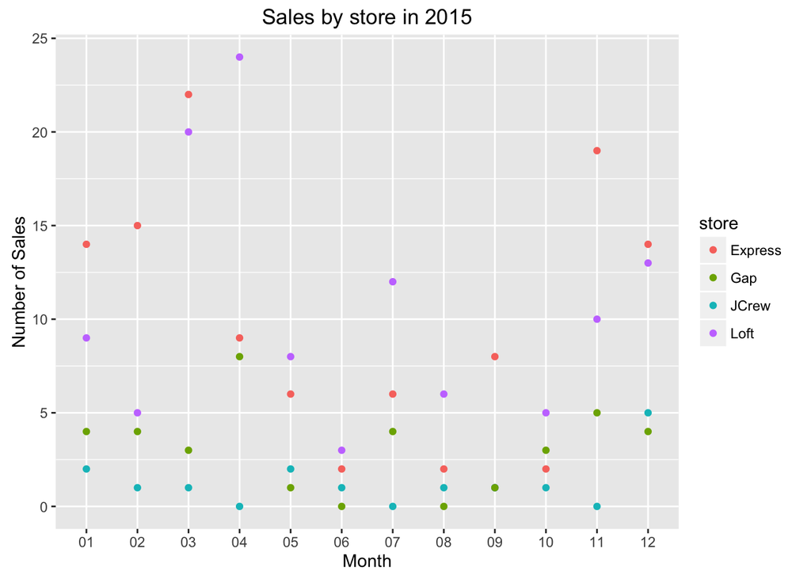

```r
#Filter data for the correct date range
dat<-dat%>%filter(date>="2015-01-01")

#Create data set with date, store, and sale (Y/N)
dat2<-dat%>%select(date,expresssale,loftsale,jcrewsale,gapsale)
dat2<-gather(dat2,store,sale,2:5)
dat2$store[dat2$store=="expresssale"]  <- "Express"
dat2$store[dat2$store=="loftsale"]  <- "Loft"
dat2$store[dat2$store=="gapsale"]  <- "Gap"
dat2$store[dat2$store=="jcrewsale"]  <- "JCrew"

#Create month/year column and monthly sales column
dat2<-dat2%>%separate(col = `date`, into = c("year", "month", "day"))
dat2<-dat2%>%group_by(month,store)%>%mutate(monthlysales=sum(sale))

#New data frame with one line per month/year for each store
dat3<-dat2%>%select(store,month,monthlysales)
dat3<-unique(dat3)

#Plot all stores on same graph for 2015
p2<-ggplot(dat3,
           aes(month,monthlysales, color=store))
p2+geom_point()+xlab("Month")+ylab("Number of Sales")+ggtitle("Sales by store in 2015")
```

# Plot: Sales by Temperature & Holiday Over Time

The plot below shows sales, average temperature, and holidays over time. The size of the points indicate number of sales across hospitals and the color of the points indicate holidays. There apperas to be no clear relationship between sales, average temperature, or holiday.

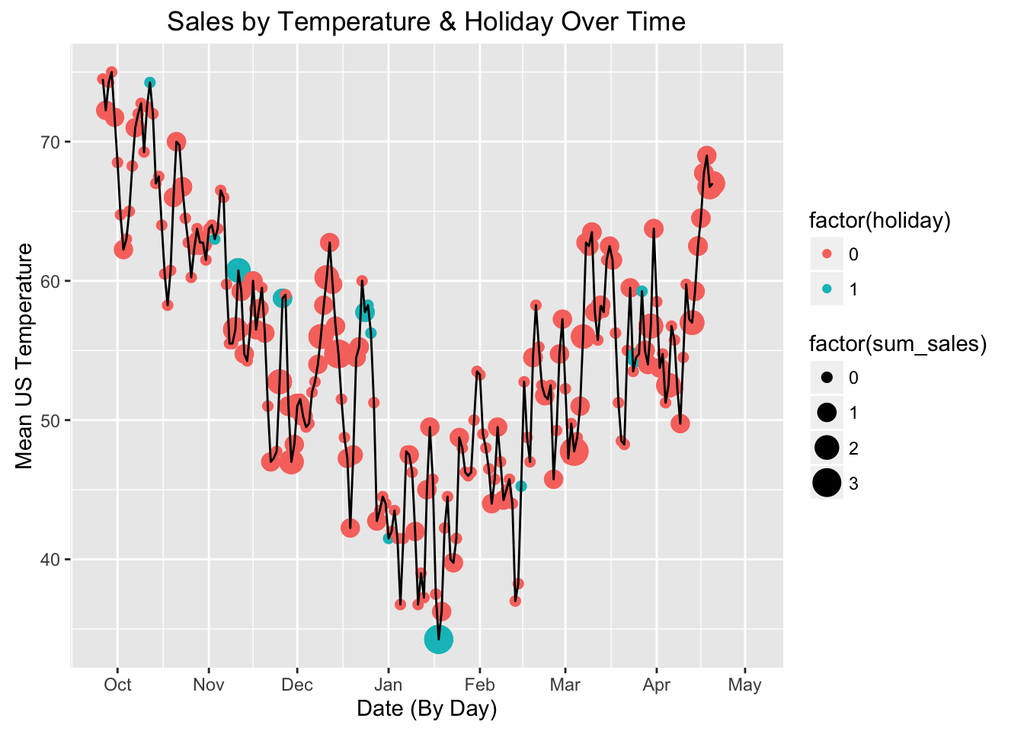

```r
# visualize weather over time, size = # sales, color = holiday
vis %>% filter(date > "2015-09-25") %>% ggplot(aes(date)) +
geom_point(aes(y = mean_temp, size = factor(sum_sales), color = factor(holiday))) +
  geom_line(aes(y = mean_temp))  +
  xlab("Date (By Day)") + ylab("Mean US Temperature") +
  ggtitle("Sales by Temperature & Holiday Over Time")
```

# Plot: Sales by Stock Price Over Time

As shown in the below plots, across stores, there is no clear relationship between stock price and sales over time.

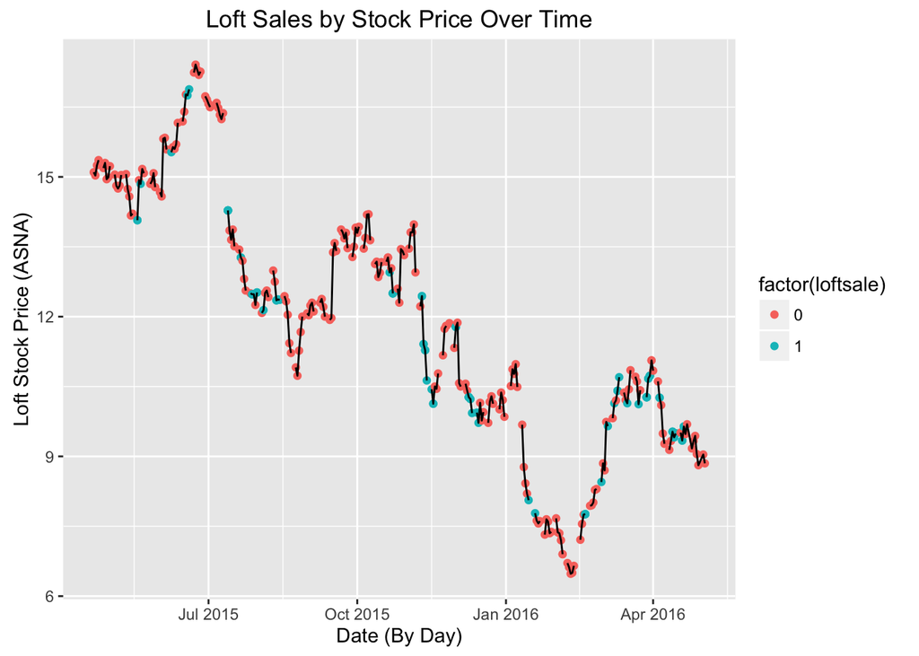

```r
# VISUALIZATION with STOCKS
# visualize stock price over time, color denotes sale day
# LOFT
vis %>% filter(date > "2015-04-20") %>%
  ggplot(aes(date)) +
  geom_point(aes(y = loft_adj_close, color = factor(loftsale))) +
  geom_line(aes(y = loft_adj_close)) +
  xlab("Date (By Day)") + ylab("Loft Stock Price (ASNA)") +
  ggtitle("Loft Sales by Stock Price Over Time")
```

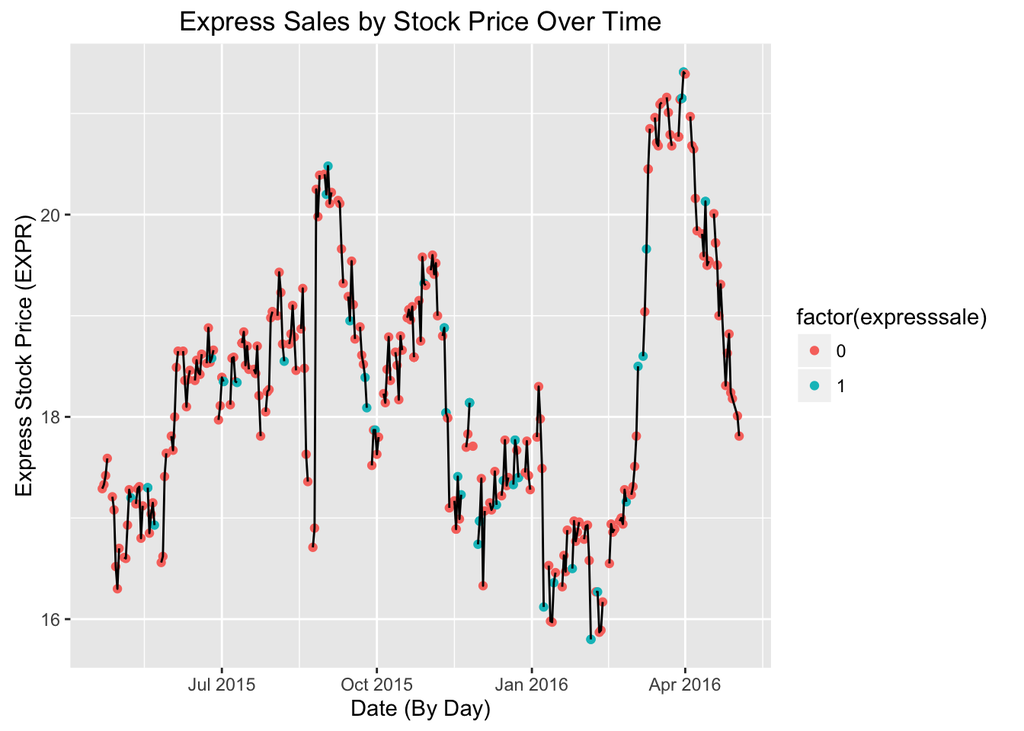

```r
# EXPRESS
vis %>% filter(date > "2015-04-20") %>%
  ggplot(aes(date)) +
  geom_point(aes(y = expr_adj_close, color = factor(expresssale))) +
  geom_line(aes(y = expr_adj_close)) +
  xlab("Date (By Day)") + ylab("Express Stock Price (EXPR)") +
  ggtitle("Express Sales by Stock Price Over Time")
```

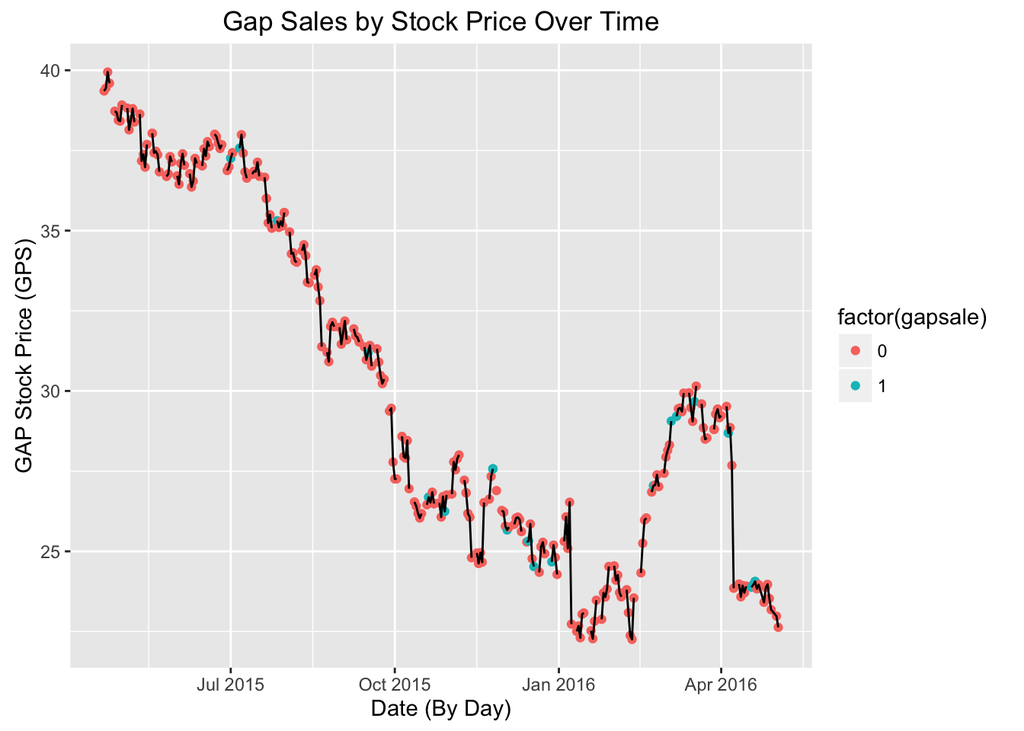

```r
# GAP
vis %>% filter(date > "2015-04-20") %>%
  ggplot(aes(date)) +
  geom_point(aes(y = gap_adj_close, color = factor(gapsale))) +
  geom_line(aes(y = gap_adj_close)) +
  xlab("Date (By Day)") + ylab("GAP Stock Price (GPS)") +
  ggtitle("Gap Sales by Stock Price Over Time")
```

# Plot: Histograms for Time From Last Sale

The histograms below show the frequency of sales across stores. Among the four stores, Express has sales most frequently, while J Crew has sales least frequently.

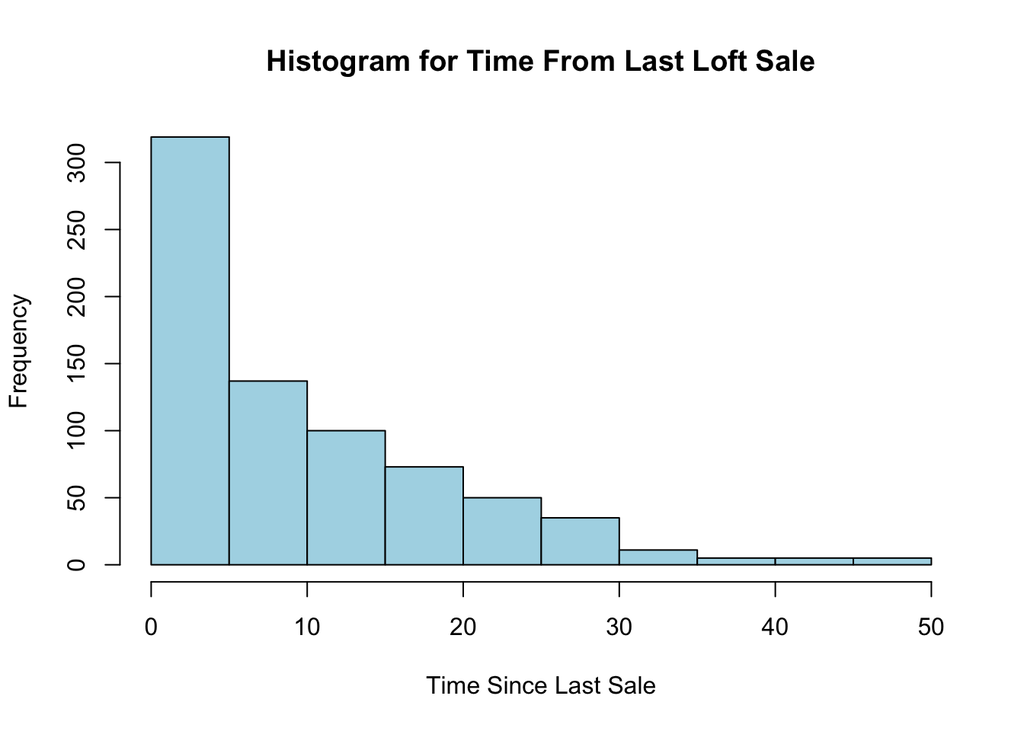

```r
# LOFT
# visualize time from last sale
hist(loft_hist$tte,
     main="Histogram for Time From Last Loft Sale",
     xlab="Time Since Last Sale",
     col="light blue")
```

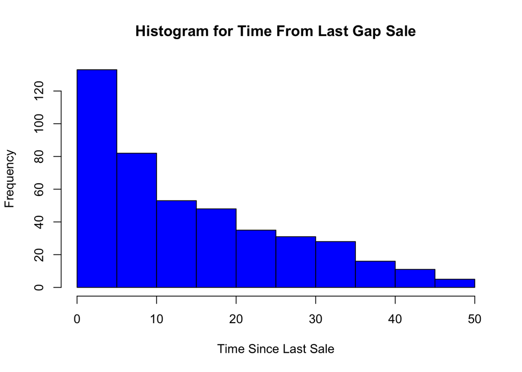

```r
# GAP
# visualize time from last sale
hist(gap_hist$tte,
     main="Histogram for Time From Last Gap Sale",
     xlab="Time Since Last Sale",
     col="blue")
```

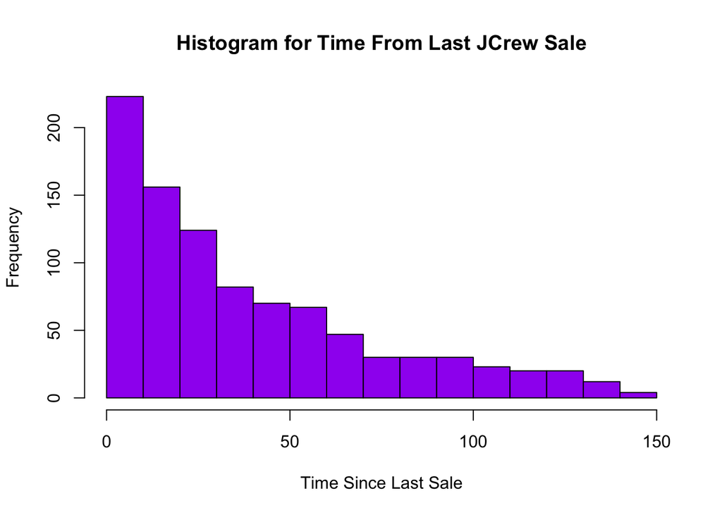

```r
# JCREW
# visualize time from last sale
hist(jcrew_hist$tte,
     main="Histogram for Time From Last JCrew Sale",
     xlab="Time Since Last Sale",
     col="purple")
```

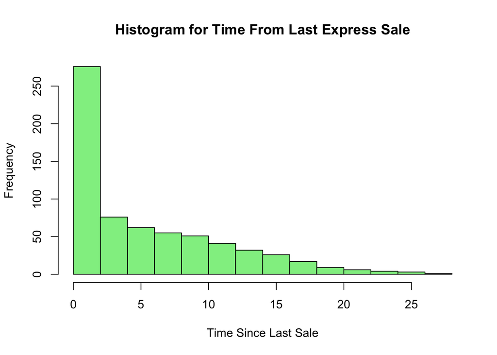

```r
# EXPRESS
# visualize time from last sale
hist(express_hist$tte,
          main="Histogram for Time From Last Express Sale",
          xlab="Time Since Last Sale",
          col="light green")
```

# 3. Predictions

We wanted to determine whether changes in our predictors are associated in changes in the outcome, retail sales. OLS is a straightforward way of determining this relationship. We also fit logistic regression models to compare to OLS because we wanted to get predictions on a probability scale (our outcome variable is dichotomous). We conducted separate analyses for each of the four stores of interest.

# EXPRESS

```r
#filter for date of furthest tweet back
express <- express %>% filter(date >= "2014-07-10" & date <= "2016-04-20")

require(data.table)

# create a time to event variable
setDT(express)[,tte := seq.int(0,.N-1L), by = cumsum(sale)-sale]

#split data
inTrain <- createDataPartition(y = express$sale, p=0.7)$Resample

#define train and test set
train_set_express <- slice(express, inTrain)
test_set_express <- slice(express, -inTrain)

#fit OLS regression to train set
express_ols <- train_set_express %>% lm(sale ~ ny_precip + ny_mean_temp + la_precip + la_mean_temp +  chi_precip + chi_mean_temp + hou_precip + hou_mean_temp + unemployment + holiday + expr_adj_close + tte, data = .)

summary(express_ols)
```

```
##
## Call:
## lm(formula = sale ~ ny_precip + ny_mean_temp + la_precip + la_mean_temp +
##     chi_precip + chi_mean_temp + hou_precip + hou_mean_temp +
##     unemployment + holiday + expr_adj_close + tte, data = .)
##
## Residuals:
##      Min       1Q   Median       3Q      Max
## -0.61239 -0.23547 -0.11026  0.03583  0.93833
##
## Coefficients:
##                  Estimate Std. Error t value Pr(>|t|)
## (Intercept)    -0.1381989  0.8793734  -0.157  0.87530
## ny_precip      -0.0332085  0.1066107  -0.311  0.75579
## ny_mean_temp   -0.0017554  0.0039818  -0.441  0.65986
## la_precip      -0.0972679  0.1868488  -0.521  0.60331
## la_mean_temp    0.0003672  0.0046776   0.079  0.93751
## chi_precip     -0.0293531  0.1030106  -0.285  0.77601
## chi_mean_temp   0.0081014  0.0041089   1.972  0.05019 .
## hou_precip      0.0230980  0.0704487   0.328  0.74339
## hou_mean_temp  -0.0087986  0.0047033  -1.871  0.06301 .
## unemployment    0.1425213  0.1152263   1.237  0.21775
## holiday         0.2579434  0.1560829   1.653  0.10016
## expr_adj_close -0.0072464  0.0244142  -0.297  0.76696
## tte            -0.0126597  0.0044812  -2.825  0.00526 **
## ---
## Signif. codes:  0 '***' 0.001 '**' 0.01 '*' 0.05 '.' 0.1 ' ' 1
##
## Residual standard error: 0.3655 on 179 degrees of freedom
##   (264 observations deleted due to missingness)
## Multiple R-squared:  0.1452, Adjusted R-squared:  0.08791
## F-statistic: 2.534 on 12 and 179 DF,  p-value: 0.004141
```

```r
#fit glm logistic regression to train set
express_glm <- train_set_express %>% glm(sale ~ ny_precip + ny_mean_temp + la_precip + la_mean_temp +  chi_precip + chi_mean_temp + hou_precip + hou_mean_temp + unemployment + holiday + expr_adj_close + tte, data=. , family = "binomial")

summary(express_glm)
```

```
##
## Call:
## glm(formula = sale ~ ny_precip + ny_mean_temp + la_precip + la_mean_temp +
##     chi_precip + chi_mean_temp + hou_precip + hou_mean_temp +
##     unemployment + holiday + expr_adj_close + tte, family = "binomial",
##     data = .)
##
## Deviance Residuals:
##     Min       1Q   Median       3Q      Max
## -1.5940  -0.6337  -0.3907  -0.1413   2.4760
##
## Coefficients:
##                Estimate Std. Error z value Pr(>|z|)
## (Intercept)    -3.04282    7.23410  -0.421  0.67403
## ny_precip      -0.44174    1.05480  -0.419  0.67537
## ny_mean_temp   -0.02111    0.03464  -0.609  0.54230
## la_precip      -3.62376    7.20352  -0.503  0.61493
## la_mean_temp    0.00169    0.03777   0.045  0.96432
## chi_precip     -0.12949    0.83693  -0.155  0.87704
## chi_mean_temp   0.06359    0.03640   1.747  0.08060 .
## hou_precip      0.21746    0.51886   0.419  0.67513
## hou_mean_temp  -0.05905    0.03820  -1.546  0.12217
## unemployment    0.93659    0.93544   1.001  0.31672
## holiday         1.27068    0.97031   1.310  0.19035
## expr_adj_close -0.07254    0.20659  -0.351  0.72549
## tte            -0.16709    0.05889  -2.837  0.00455 **
## ---
## Signif. codes:  0 '***' 0.001 '**' 0.01 '*' 0.05 '.' 0.1 ' ' 1
##
## (Dispersion parameter for binomial family taken to be 1)
##
##     Null deviance: 179.31  on 191  degrees of freedom
## Residual deviance: 146.83  on 179  degrees of freedom
##   (264 observations deleted due to missingness)
## AIC: 172.83
##
## Number of Fisher Scoring iterations: 7
```

```r
#try ols on test set to check accuracy
test_set_express <- mutate(test_set_express, fhat_express_ols = predict(express_ols, newdata = test_set_express, type = "response")) %>%
  mutate(pred_express_ols=round(fhat_express_ols)) %>% mutate(accuracy_express_ols = (ifelse(pred_express_ols == sale, 1, 0)))

table(test_set_express$accuracy_express_ols)
```

```
##
##  0  1
## 21 57
```

```r
#try glm on test set to check accuracy
test_set_express <- mutate(test_set_express, fhat_express_glm = predict(express_glm, newdata = test_set_express, type = "response")) %>%
  mutate(pred_express_glm=round(fhat_express_glm)) %>% mutate(accuracy_express_glm = (ifelse(pred_express_glm == sale, 1, 0)))

table(prediction = test_set_express$pred_express_glm, truth = test_set_express$sale)
```

```
##           truth
## prediction  0  1
##          0 57 19
##          1  2  0
```

```r
table(test_set_express$sale)
```

```
##
##   0   1
## 155  40
```

```r
#confusion matrix ols
tab <- table(pred = test_set_express$pred_express_ols, truth = test_set_express$sale)
cm_express_ols <- confusionMatrix(tab)
cm_express_ols$table
```

```
##     truth
## pred  0  1
##    0 57 19
##    1  2  0
```

```r
cm_express_ols$overall["Accuracy"]
```

```
##  Accuracy
## 0.7307692
```

```r
#confusion matrix glm
tab <- table(test_set_express$pred_express_glm, test_set_express$sale)
cm_express_glm <- confusionMatrix(tab)
cm_express_glm $table
```

```
##
##      0  1
##   0 57 19
##   1  2  0
```

```r
cm_express_glm $overall["Accuracy"]
```

```
##  Accuracy
## 0.7307692
```

# GAP

```r
#filter for date of furthest tweet back
gap <- gap %>% filter(date >= "2015-02-12" & date <= "2016-04-20")

require(data.table)

# create a time to event variable
setDT(gap)[,tte := seq.int(0,.N-1L), by = cumsum(sale)-sale]

#split data
inTrain <- createDataPartition(y = gap$sale, p=0.7)$Resample

#define train and test set
train_set_gap <- slice(gap, inTrain)
test_set_gap <- slice(gap, -inTrain)

#fit OLS regression to train set
gap_ols <- train_set_gap %>% lm(sale ~ ny_precip + ny_mean_temp + la_precip + la_mean_temp +  chi_precip + chi_mean_temp + hou_precip + hou_mean_temp + unemployment + holiday +gap_adj_close +tte, data=.)

summary(gap_ols)
```

```
##
## Call:
## lm(formula = sale ~ ny_precip + ny_mean_temp + la_precip + la_mean_temp +
##     chi_precip + chi_mean_temp + hou_precip + hou_mean_temp +
##     unemployment + holiday + gap_adj_close + tte, data = .)
##
## Residuals:
##      Min       1Q   Median       3Q      Max
## -0.17376 -0.07863 -0.03670 -0.01487  0.97616
##
## Coefficients:
##                 Estimate Std. Error t value Pr(>|t|)
## (Intercept)    0.9626527  1.3741941   0.701    0.485
## ny_precip      0.0763559  0.0823673   0.927    0.356
## ny_mean_temp  -0.0002422  0.0029922  -0.081    0.936
## la_precip     -0.1101713  0.1913668  -0.576    0.566
## la_mean_temp   0.0006415  0.0036457   0.176    0.861
## chi_precip    -0.0118457  0.0912880  -0.130    0.897
## chi_mean_temp  0.0029876  0.0031232   0.957    0.341
## hou_precip     0.0530088  0.0602354   0.880    0.381
## hou_mean_temp -0.0049918  0.0039204  -1.273    0.206
## unemployment  -0.2056803  0.3156249  -0.652    0.516
## holiday       -0.0460921  0.2294305  -0.201    0.841
## gap_adj_close  0.0083187  0.0120739   0.689    0.492
## tte            0.0024129  0.0017263   1.398    0.165
##
## Residual standard error: 0.2238 on 108 degrees of freedom
##   (183 observations deleted due to missingness)
## Multiple R-squared:  0.05121,    Adjusted R-squared:  -0.05421
## F-statistic: 0.4857 on 12 and 108 DF,  p-value: 0.9193
```

```r
#fit glm logistic regression to train set
gap_glm <- train_set_gap %>% glm(sale ~ ny_precip + ny_mean_temp + la_precip + la_mean_temp +  chi_precip + chi_mean_temp + hou_precip + hou_mean_temp + unemployment + holiday + gap_adj_close + tte, data=. , family = "binomial")
summary(gap_glm)
```

```
##
## Call:
## glm(formula = sale ~ ny_precip + ny_mean_temp + la_precip + la_mean_temp +
##     chi_precip + chi_mean_temp + hou_precip + hou_mean_temp +
##     unemployment + holiday + gap_adj_close + tte, family = "binomial",
##     data = .)
##
## Deviance Residuals:
##     Min       1Q   Median       3Q      Max
## -0.8974  -0.3636  -0.2197  -0.1523   2.7120
##
## Coefficients:
##                 Estimate Std. Error z value Pr(>|z|)
## (Intercept)    1.902e+01  3.157e+01   0.603    0.547
## ny_precip      1.937e+00  1.644e+00   1.178    0.239
## ny_mean_temp  -1.949e-04  5.851e-02  -0.003    0.997
## la_precip     -1.275e+03  1.810e+05  -0.007    0.994
## la_mean_temp  -1.163e-02  8.184e-02  -0.142    0.887
## chi_precip    -5.322e-01  1.945e+00  -0.274    0.784
## chi_mean_temp  7.857e-02  7.083e-02   1.109    0.267
## hou_precip     8.104e-01  9.539e-01   0.850    0.396
## hou_mean_temp -1.246e-01  9.129e-02  -1.365    0.172
## unemployment  -5.005e+00  7.377e+00  -0.678    0.497
## holiday       -2.024e+01  7.946e+04   0.000    1.000
## gap_adj_close  2.449e-01  2.923e-01   0.838    0.402
## tte            5.233e-02  3.836e-02   1.364    0.173
##
## (Dispersion parameter for binomial family taken to be 1)
##
##     Null deviance: 47.746  on 120  degrees of freedom
## Residual deviance: 40.658  on 108  degrees of freedom
##   (183 observations deleted due to missingness)
## AIC: 66.658
##
## Number of Fisher Scoring iterations: 22
```

```r
#try ols on test set to check accuracy
test_set_gap <- mutate(test_set_gap, fhat_gap_ols = predict(gap_ols, newdata = test_set_gap, type = "response")) %>%
  mutate(pred_gap_ols=round(fhat_gap_ols)) %>% mutate(accuracy_gap_ols = (ifelse(pred_gap_ols == sale, 1, 0)))

table(test_set_gap$accuracy_gap_ols)
```

```
##
##  0  1
##  1 58
```

```r
#try glm on test set to check accuracy
test_set_gap <- mutate(test_set_gap, fhat_gap_glm = predict(gap_glm, newdata = test_set_gap, type = "response")) %>%
  mutate(pred_gap_glm=round(fhat_gap_glm)) %>% mutate(accuracy_gap_glm = (ifelse(pred_gap_glm == sale, 1, 0)))

table(test_set_gap$accuracy_gap_glm)
```

```
##
##  0  1
##  2 57
```

```r
#confusion matrix ols
#tab <- table(test_set_gap$pred_gap_ols, test_set_gap$sale)
#cm_gap_ols <- confusionMatrix(tab)
#cm_gap_ols $table
#cm_gap_ols $overall["Accuracy"]

#confusion matrix glm
#tab <- table(test_set_gap$pred_gap_glm, test_set_gap$sale)
#cm_gap_glm <- confusionMatrix(tab)
#cm_gap_glm$table
#cm_gap_glm$overall["Accuracy"]
```

We are always predicting “0” for both OLS and GLM. Again, none of the predictors we used in the model (temperature, precipitation, unemployment, holiday, stock price, time from last sale) are significant at the alpha = 0.05 level.

# LOFT

```r
loft <- loft %>% filter(date >= "2014-04-20" & date <= "2016-04-20")

require(data.table)

# create a time to event variable
setDT(loft)[,tte := seq.int(0,.N-1L), by = cumsum(sale)-sale]

#split data
inTrain <- createDataPartition(y = loft$sale, p=0.7)$Resample

#define train and test set
train_set_loft <- slice(loft, inTrain)
test_set_loft <- slice(loft, -inTrain)

#fit OLS regression to train set
loft_ols <- train_set_loft %>% lm(sale ~ ny_precip + ny_mean_temp + la_precip + la_mean_temp +  chi_precip + chi_mean_temp + hou_precip + hou_mean_temp + unemployment + holiday + loft_adj_close + tte, data=.)

summary(loft_ols)
```

```
##
## Call:
## lm(formula = sale ~ ny_precip + ny_mean_temp + la_precip + la_mean_temp +
##     chi_precip + chi_mean_temp + hou_precip + hou_mean_temp +
##     unemployment + holiday + loft_adj_close + tte, data = .)
##
## Residuals:
##      Min       1Q   Median       3Q      Max
## -0.51042 -0.18370 -0.12693 -0.05538  0.96984
##
## Coefficients:
##                 Estimate Std. Error t value Pr(>|t|)
## (Intercept)    -0.056253   0.450191  -0.125   0.9007
## ny_precip      -0.025860   0.077633  -0.333   0.7394
## ny_mean_temp    0.001667   0.003599   0.463   0.6437
## la_precip      -0.008568   0.192711  -0.044   0.9646
## la_mean_temp   -0.004922   0.004236  -1.162   0.2465
## chi_precip     -0.034288   0.073173  -0.469   0.6398
## chi_mean_temp  -0.006119   0.003593  -1.703   0.0900 .
## hou_precip      0.094014   0.051323   1.832   0.0684 .
## hou_mean_temp   0.011163   0.004861   2.296   0.0226 *
## unemployment    0.079961   0.086222   0.927   0.3548
## holiday         0.081170   0.172811   0.470   0.6390
## loft_adj_close -0.031580   0.017875  -1.767   0.0787 .
## tte            -0.001578   0.002369  -0.666   0.5059
## ---
## Signif. codes:  0 '***' 0.001 '**' 0.01 '*' 0.05 '.' 0.1 ' ' 1
##
## Residual standard error: 0.3709 on 217 degrees of freedom
##   (283 observations deleted due to missingness)
## Multiple R-squared:  0.05905,    Adjusted R-squared:  0.00702
## F-statistic: 1.135 on 12 and 217 DF,  p-value: 0.3331
```

```r
#fit glm logistic regression to train set
loft_glm <- train_set_loft %>% glm(sale ~ ny_precip + ny_mean_temp + la_precip + la_mean_temp +  chi_precip + chi_mean_temp + hou_precip + hou_mean_temp + unemployment + holiday + loft_adj_close + tte, data=. , family = "binomial")

summary(loft_glm)
```

```
##
## Call:
## glm(formula = sale ~ ny_precip + ny_mean_temp + la_precip + la_mean_temp +
##     chi_precip + chi_mean_temp + hou_precip + hou_mean_temp +
##     unemployment + holiday + loft_adj_close + tte, family = "binomial",
##     data = .)
##
## Deviance Residuals:
##     Min       1Q   Median       3Q      Max
## -1.3889  -0.6115  -0.5042  -0.3896   2.3556
##
## Coefficients:
##                 Estimate Std. Error z value Pr(>|z|)
## (Intercept)    -3.711899   3.437357  -1.080   0.2802
## ny_precip      -0.164475   0.623015  -0.264   0.7918
## ny_mean_temp    0.013306   0.027065   0.492   0.6230
## la_precip      -0.006221   1.614675  -0.004   0.9969
## la_mean_temp   -0.037511   0.031628  -1.186   0.2356
## chi_precip     -0.281649   0.664821  -0.424   0.6718
## chi_mean_temp  -0.045946   0.027605  -1.664   0.0960 .
## hou_precip      0.598504   0.323227   1.852   0.0641 .
## hou_mean_temp   0.084699   0.037988   2.230   0.0258 *
## unemployment    0.609824   0.680297   0.896   0.3700
## holiday         0.653271   1.200029   0.544   0.5862
## loft_adj_close -0.223003   0.133623  -1.669   0.0951 .
## tte            -0.012876   0.019156  -0.672   0.5015
## ---
## Signif. codes:  0 '***' 0.001 '**' 0.01 '*' 0.05 '.' 0.1 ' ' 1
##
## (Dispersion parameter for binomial family taken to be 1)
##
##     Null deviance: 206.18  on 229  degrees of freedom
## Residual deviance: 193.00  on 217  degrees of freedom
##   (283 observations deleted due to missingness)
## AIC: 219
##
## Number of Fisher Scoring iterations: 5
```

```r
#try ols on test set to check accuracy
test_set_loft <- mutate(test_set_loft, fhat_loft_ols = predict(loft_ols, newdata = test_set_loft, type = "response")) %>%
  mutate(pred_loft_ols=round(fhat_loft_ols)) %>% mutate(accuracy_loft_ols = (ifelse(pred_loft_ols == sale, 1, 0)))

table(test_set_loft$accuracy_loft_ols)
```

```
##
##  0  1
## 14 72
```

```r
#try glm on test set to check accuracy
test_set_loft <- mutate(test_set_loft, fhat_loft_glm = predict(loft_glm, newdata = test_set_loft, type = "response")) %>%
  mutate(pred_loft_glm=round(fhat_loft_glm)) %>% mutate(accuracy_loft_glm = (ifelse(pred_loft_glm == sale, 1, 0)))

table(test_set_loft$accuracy_loft_glm)
```

```
##
##  0  1
## 14 72
```

```r
#confusion matrix ols
#tab <- table(test_set_loft$pred_loft_ols, test_set_loft$sale)
#cm_loft_ols <- confusionMatrix(tab)
#cm_loft_ols $table
#cm_loft_ols $overall["Accuracy"]

#confusion matrix glm
#tab <- table(test_set_loft$pred_loft_glm, test_set_loft$sale)
#cm_loft_glm <- confusionMatrix(tab)
#cm_loft_glm$table
#cm_loft_glm$overall["Accuracy"]
```

# JCREW

```r
jcrew <- jcrew %>% filter(date >= "2013-09-25"& date <= "2016-04-20")

# create a time to event variable
setDT(jcrew)[,tte := seq.int(0,.N-1L), by = cumsum(sale)-sale]

#split data
inTrain <- createDataPartition(y = jcrew$sale, p=0.7)$Resample

#define train and test set
train_set_jcrew <- slice(jcrew, inTrain)
test_set_jcrew <- slice(jcrew, -inTrain)

#fit OLS regression to train set
jcrew_ols <- train_set_jcrew %>% lm(sale ~ ny_precip + ny_mean_temp + la_precip + la_mean_temp +  chi_precip + chi_mean_temp + hou_precip + hou_mean_temp + unemployment + holiday +tte, data=.)

summary(jcrew_ols)
```

```
##
## Call:
## lm(formula = sale ~ ny_precip + ny_mean_temp + la_precip + la_mean_temp +
##     chi_precip + chi_mean_temp + hou_precip + hou_mean_temp +
##     unemployment + holiday + tte, data = .)
##
## Residuals:
##      Min       1Q   Median       3Q      Max
## -0.13543 -0.05263 -0.03788 -0.01775  0.97658
##
## Coefficients:
##                 Estimate Std. Error t value Pr(>|t|)
## (Intercept)    0.1813838  0.1337673   1.356   0.1759
## ny_precip      0.0137352  0.0320947   0.428   0.6689
## ny_mean_temp  -0.0017680  0.0012618  -1.401   0.1619
## la_precip     -0.0283753  0.0658007  -0.431   0.6665
## la_mean_temp  -0.0026887  0.0016047  -1.675   0.0946 .
## chi_precip    -0.0362717  0.0283680  -1.279   0.2018
## chi_mean_temp  0.0010327  0.0013473   0.767   0.4438
## hou_precip    -0.0077352  0.0185100  -0.418   0.6762
## hou_mean_temp  0.0016817  0.0016386   1.026   0.3054
## unemployment  -0.0032686  0.0142660  -0.229   0.8189
## holiday        0.0481746  0.0432641   1.114   0.2662
## tte           -0.0002792  0.0003062  -0.912   0.3623
## ---
## Signif. codes:  0 '***' 0.001 '**' 0.01 '*' 0.05 '.' 0.1 ' ' 1
##
## Residual standard error: 0.1936 on 400 degrees of freedom
##   (246 observations deleted due to missingness)
## Multiple R-squared:  0.02462,    Adjusted R-squared:  -0.002199
## F-statistic: 0.918 on 11 and 400 DF,  p-value: 0.5228
```

```r
#fit glm logistic regression to train set
jcrew_glm <- train_set_jcrew %>% glm(sale ~ ny_precip + ny_mean_temp + la_precip + la_mean_temp +  chi_precip + chi_mean_temp + hou_precip + hou_mean_temp + unemployment + holiday, data=. , family = "binomial")

summary(jcrew_glm)
```

```
##
## Call:
## glm(formula = sale ~ ny_precip + ny_mean_temp + la_precip + la_mean_temp +
##     chi_precip + chi_mean_temp + hou_precip + hou_mean_temp +
##     unemployment + holiday, family = "binomial", data = .)
##
## Deviance Residuals:
##     Min       1Q   Median       3Q      Max
## -0.7626  -0.3095  -0.2409  -0.1660   2.7461
##
## Coefficients:
##               Estimate Std. Error z value Pr(>|z|)
## (Intercept)    0.50445    3.51990   0.143   0.8860
## ny_precip      0.33104    0.82437   0.402   0.6880
## ny_mean_temp  -0.05156    0.03328  -1.549   0.1214
## la_precip     -0.51568    1.84847  -0.279   0.7803
## la_mean_temp  -0.08407    0.04716  -1.783   0.0746 .
## chi_precip    -3.45693    2.54441  -1.359   0.1743
## chi_mean_temp  0.04206    0.03546   1.186   0.2356
## hou_precip    -0.18543    0.62421  -0.297   0.7664
## hou_mean_temp  0.04449    0.04053   1.098   0.2723
## unemployment  -0.07572    0.39444  -0.192   0.8478
## holiday        0.89607    0.84552   1.060   0.2892
## ---
## Signif. codes:  0 '***' 0.001 '**' 0.01 '*' 0.05 '.' 0.1 ' ' 1
##
## (Dispersion parameter for binomial family taken to be 1)
##
##     Null deviance: 135.32  on 411  degrees of freedom
## Residual deviance: 124.00  on 401  degrees of freedom
##   (246 observations deleted due to missingness)
## AIC: 146
##
## Number of Fisher Scoring iterations: 8
```

```r
#try ols on test set to check accuracy
test_set_jcrew <- mutate(test_set_jcrew, fhat_jcrew_ols = predict(jcrew_ols, newdata = test_set_jcrew, type = "response")) %>%
  mutate(pred_jcrew_ols=round(fhat_jcrew_ols)) %>% mutate(accuracy_jcrew_ols = (ifelse(pred_jcrew_ols == sale, 1, 0)))

table(test_set_jcrew$accuracy_jcrew_ols)
```

```
##
##   0   1
##   3 169
```

```r
#try glm on test set to check accuracy
test_set_jcrew <- mutate(test_set_jcrew, fhat_jcrew_glm = predict(jcrew_glm, newdata = test_set_jcrew, type = "response")) %>%
  mutate(pred_jcrew_glm=round(fhat_jcrew_glm)) %>% mutate(accuracy_jcrew_glm = (ifelse(pred_jcrew_glm == sale, 1, 0)))

table(test_set_jcrew$accuracy_jcrew_glm)
```

```
##
##   0   1
##   3 169
```

```r
#confusion matrix ols
#tab <- table(test_set_jcrew$pred_jcrew_ols, test_set_jcrew$sale)
#cm_jcrew_ols <- confusionMatrix(tab)
#cm_jcrew_ols $table
#cm_jcrew_ols $overall["Accuracy"]

#confusion matrix glm
#tab <- table(test_set_jcrew$pred_jcrew_glm, test_set_jcrew$sale)
#cm_jcrew_glm <- confusionMatrix(tab)
#cm_jcrew_glm$table
#cm_jcrew_glm$overall["Accuracy"]
```

We are always predicting “0” for both OLS and GLM. Again, none of the predictors we used in the model (temperature, precipitation, unemployment, holiday, stock price, time from last sale) are significant at the alpha = 0.05 level.

# Discussion

Both our OLS and our logistic regression models almost always predict that there is less than a 50% chance of a sale. This means that we can accurately predict when there is no sale, but our models aren’t meaningful for predicting when sales will happen. As a result, accuracy metrics do not fully communicate the appropriateness of our models for predicting the outcome of interest. In other words, accuracy metrics mainly reflect our ability to predict when there is no sale because we are almost always predicting a low chance of having a sale. This is because our predictor variables jointly have very limited predictive power on our outcome of interest “sale”.